# Recommendation System Project_Hemlata

### Project 5: Recommendation System Project

### Data Description:

### Domain: Smartphone, Electronics

### Context:

India is the second largest market globally for smartphones after China. About 134 million smartphones were sold across India in the year 2017 and is estimated to increase to about 442 million in 2022. India ranked second in the average time spent on mobile web by smartphone users across Asia Paci ic. The combination of very high sales volumes and the average smartphone consumer behaviour has made India a very attractive market for foreign vendors. As per Consumer behaviour, 97% of consumers turn to a search engine when they are buying a product vs. 15% who turn to social media. If a seller succeeds to publish smartphones based on user’s behaviour/choice at the right place, there are 90% chances that user will enquire for the same. This Case Study is targeted to build a recommendation system based on individual consumer’s behaviour or choice.

### Data Description:

#### author : name of the person who gave the rating

#### country : country the person who gave the rating belongs to

#### data : date of the rating

#### domain: website from which the rating was taken from

#### extract: rating content

#### language: language in which the rating was given

#### product: name of the product/mobile phone for which the rating was given

#### score: average rating for the phone

#### score_max: highest rating given for the phone

#### source: source from where the rating was taken

### Learning Outcomes:

### Objective:

We will build a recommendation system using popularity based and collaborative filtering methods to recommend mobile phones to a user which are most popular and personalised respectively.

## Steps and tasks: [ Total Score: 60 points]

### Task 1: Import the necessary libraries and read the provided CSVs as a data frame and perform the below steps.

1. Merge the provided CSVs into one data-frame.
2. Check a few observations and shape of the data-frame.
3. Round off scores to the nearest integers.
4. Check for missing values. Impute the missing values if there is any.
5. Check for duplicate values and remove them if there is any.
6. Keep only 1000000 data samples. Use random state=612.
7. Drop irrelevant features. Keep features like Author, Product, and Score.

```python
#!pip install surprise
```

```python
import numpy as np # linear algebra
import pandas as pd # data processing, CSV file I/O (e.g. pd.read_csv)
import matplotlib.pyplot as plt       # matplotlib.pyplot plots data
%matplotlib inline

from sklearn.metrics.pairwise import cosine_similarity
from sklearn.feature_extraction.text import CountVectorizer
from surprise import KNNWithMeans
from surprise import accuracy
from surprise.model_selection import train_test_split
```

```python
#help(pd.read_csv)
```

```python
Data1 = pd.read_csv("Data Set/phone_user_review_file_1.csv",error_bad_lines=False,encoding='latin1')
Data1.shape
```

```
(374910, 11)
```

```python
Data2 = pd.read_csv("Data Set/phone_user_review_file_2.csv",error_bad_lines=False,encoding='latin1')
Data2.head()
Data2.shape
```

```
(114925, 11)
```

```python
Data3 = pd.read_csv("Data Set/phone_user_review_file_3.csv",error_bad_lines=False,encoding='latin1')
#Data3.head()
Data3.shape
```

```
(312961, 11)
```

```python
Data4 = pd.read_csv("Data Set/phone_user_review_file_4.csv",error_bad_lines=False,encoding='latin1')
#Data3.head()
Data4.shape
```

```
(98284, 11)
```

```python
Data5 = pd.read_csv("Data Set/phone_user_review_file_5.csv",error_bad_lines=False,encoding='latin1')
#Data3.head()
Data5.shape
```

```
(350216, 11)
```

```python
Data6 = pd.read_csv("Data Set/phone_user_review_file_6.csv",error_bad_lines=False,encoding='latin1')
#Data3.head()
Data6.shape
```

```
(163837, 11)
```

```python
frames = [Data1,Data2,Data3,Data4,Data5,Data6]
rec_Data = pd.concat(frames)
```

```python
rec_Data.shape
```

```
(1415133, 11)
```

```python
rec_Data.head()
```

|  | phone_url | date | lang | country | source | domain | score | score_max | extract | author | product |
| --- | --- | --- | --- | --- | --- | --- | --- | --- | --- | --- | --- |
| 0 | /cellphones/samsung-galaxy-s8/ | 5/2/2017 | en | us | Verizon Wireless | verizonwireless.com | 10.0 | 10.0 | As a diehard Samsung fan who has had every Sam... | CarolAnn35 | Samsung Galaxy S8 |
| 1 | /cellphones/samsung-galaxy-s8/ | 4/28/2017 | en | us | Phone Arena | phonearena.com | 10.0 | 10.0 | Love the phone. the phone is sleek and smooth ... | james0923 | Samsung Galaxy S8 |
| 2 | /cellphones/samsung-galaxy-s8/ | 5/4/2017 | en | us | Amazon | amazon.com | 6.0 | 10.0 | Adequate feel. Nice heft. Processor's still sl... | R. Craig | Samsung Galaxy S8 (64GB) G950U 5.8" 4G LTE Unl... |
| 3 | /cellphones/samsung-galaxy-s8/ | 5/2/2017 | en | us | Samsung | samsung.com | 9.2 | 10.0 | Never disappointed. One of the reasons I've be... | Buster2020 | Samsung Galaxy S8 64GB (AT&T) |
| 4 | /cellphones/samsung-galaxy-s8/ | 5/11/2017 | en | us | Verizon Wireless | verizonwireless.com | 4.0 | 10.0 | I've now found that i'm in a group of people t... | S Ate Mine | Samsung Galaxy S8 |

Dataset has 1 Million 415 thousand and one hundred thirty three records.

```python
rec_Data.info()
```

```
<class 'pandas.core.frame.DataFrame'>
Int64Index: 1415133 entries, 0 to 163836
Data columns (total 11 columns):
 #   Column     Non-Null Count    Dtype
---  ------     --------------    -----
 0   phone_url  1415133 non-null  object
 1   date       1415133 non-null  object
 2   lang       1415133 non-null  object
 3   country    1415133 non-null  object
 4   source     1415133 non-null  object
 5   domain     1415133 non-null  object
 6   score      1351644 non-null  float64
 7   score_max  1351644 non-null  float64
 8   extract    1395772 non-null  object
 9   author     1351931 non-null  object
 10  product    1415132 non-null  object
dtypes: float64(2), object(9)
memory usage: 129.6+ MB
```

There are total 11 columns in the dataset. Few entreis are missing in the dataset. score and score_max columns are numerical and other columns are of object type.

```python
rec_Data.describe().transpose()
```

|  | count | mean | std | min | 25% | 50% | 75% | max |
| --- | --- | --- | --- | --- | --- | --- | --- | --- |
| score | 1351644.0 | 8.00706 | 2.616121 | 0.2 | 7.2 | 9.2 | 10.0 | 10.0 |
| score_max | 1351644.0 | 10.00000 | 0.000000 | 10.0 | 10.0 | 10.0 | 10.0 | 10.0 |

```python
#Round off scores to the nearest integers.
rec_Data.score = rec_Data.score.apply(np.round)
```

```python
#Check for missing values. Impute the missing values if there is any.
rec_Data.isnull().sum()
```

```
phone_url        0
date             0
lang             0
country          0
source           0
domain           0
score        63489
score_max    63489
extract      19361
author       63202
product          1
dtype: int64
```

```python
rec_Data['score'].fillna(rec_Data['score'].median(),inplace=True)
rec_Data['score_max'].fillna(rec_Data['score_max'].median(),inplace=True)
```

```python
rec_Data.isnull().sum()
```

```
phone_url        0
date             0
lang             0
country          0
source           0
domain           0
score            0
score_max        0
extract      19361
author       63202
product          1
dtype: int64
```

```python
rec_Data.dropna(inplace=True)
```

```python
rec_Data.shape
```

```
(1336416, 11)
```

```python
#Check for duplicate values and remove them if there is any.
rec_Data.duplicated().sum()
```

```
4823
```

```python
rec_Data.drop_duplicates(keep = False, inplace = True)
```

```python
rec_Data.shape
```

```
(1327321, 11)
```

### Task 9. Check for outliers and impute them as required.

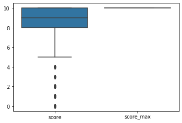

```python
import seaborn as sns
sns.boxplot(data=rec_Data)
```

```python
rec_Data[rec_Data['score']< 3]['score'].count()
```

```
125600
```

```python
rec_Data.shape
```

```
(1327321, 11)
```

### This code using mean and std is taking too long to remove outliers

#### calculate summary statistics

data_mean, data_std = np.mean(rec_Data), np.std(rec_Data)

#### remove outliers

new_df.shape

### Score column consists some outliers

Tried to remove outliers using quantile method, but if we take 24 percentile and 75 percentile and compute IQR, it removes 200126 records from the dataset. If we take 25 and 75 percentile, it removes more records and we do not get 1 million records for processing. So 24 and 75 percentile is considered.

```python
Q1=rec_Data['score'].quantile(0.24)
Q3=rec_Data['score'].quantile(0.75)
IQR=Q3-Q1
print(Q1)
print(Q3)
print(IQR)
```

```
8.0
10.0
2.0
```

```python
Lower_Whisker = Q1-1.5*IQR
Upper_Whisker = Q3+1.5*IQR
print(Lower_Whisker, Upper_Whisker)
```

```
5.0 13.0
```

```python
rec_Data[rec_Data['score']<=Lower_Whisker].shape
```

```
(200126, 11)
```

```python
data_new1 = rec_Data[rec_Data['score']<=Lower_Whisker]
data_new1.shape
```

```
(200126, 11)
```

```python
rec_Data_new = rec_Data[rec_Data['score']> Lower_Whisker]
```

```python
rec_Data.shape
```

```
(1327321, 11)
```

```python
#Keep only 1000000 data samples. Use random state=612
rec_Data = rec_Data.sample(n=1000000,random_state=612)
```

```python
rec_Data.shape
```

```
(1000000, 11)
```

```python
rec_Data.head()
```

|  | phone_url | date | lang | country | source | domain | score | score_max | extract | author | product |
| --- | --- | --- | --- | --- | --- | --- | --- | --- | --- | --- | --- |
| 99002 | /cellphones/sony-xperia-z1-compact-d5503/ | 3/27/2014 | en | us | Amazon | amazon.com | 10.0 | 10.0 | I'd only owned Samsung before. But Sony is rea... | Barry T. | Sony Xperia Z1 Compact D5503 Android Smartphon... |
| 236502 | /cellphones/doro-liberto-820/ | 12/6/2014 | en | gb | Amazon | amazon.co.uk | 10.0 | 10.0 | My savvy grandson bought this for me as a suit... | Robert Harris | Doro Liberto 820 SIM-Free Smartphone - Black/S... |
| 99154 | /cellphones/samsung-galaxy-ace-s5830/ | 12/10/2013 | fr | fr | Ciao | ciao.fr | 4.0 | 10.0 | Je rejoins l'avis précédent! Au départ, je ... | llunell | Samsung Galaxy Ace S5830i |
| 147653 | /cellphones/htc-desire-10-lifestyle/ | 11/23/2016 | en | in | Amazon | amazon.in | 10.0 | 10.0 | very good product from HTC | Amazon Customer | HTC Desire 10 Lifestyle (Polar White, 32 GB) -... |
| 143947 | /cellphones/samsung-galaxy-a5-2016/ | 7/22/2016 | ru | ru | Yandex | market.yandex.ru | 10.0 | 10.0 | Ñ Ð¾ÑÐ¾ÑÐ¸Ð¹ ÑÐµÐ»ÐµÑÐ¾Ð½. Ð·Ð¼Ð¾Ð¶Ð½Ð¾ Ð½... | lizerginiy | Samsung Galaxy A5 (2016) SM-A510F |

```python
rec_Data.columns
```

```
Index(['phone_url', 'date', 'lang', 'country', 'source', 'domain', 'score',
       'score_max', 'extract', 'author', 'product'],
      dtype='object')
```

```python
rec_Data['extract']
```

```
99002     I'd only owned Samsung before. But Sony is rea...
236502    My savvy grandson bought this for me as a suit...
99154     Je rejoins l'avis prÃ©cÃ©dent! Au dÃ©part, je ...
147653                           very good product from HTC
143947    Ñ
Ð¾ÑÐ¾ÑÐ¸Ð¹ ÑÐµÐ»ÐµÑÐ¾Ð½. Ð·Ð¼Ð¾Ð¶Ð½Ð¾ Ð½...
                                ...
72988     Es rapido rapido rapido Mejorable la calidad d...
186598    Great feel...Ease of use...Speed...Free music(...
254554    Ho comprato HTC One nell passato e mi sono tro...
83277     top toestel werkt super goed. in het begin was...
267651    Ik ben zeer tevreden over mijn nieuwe iPhone. ...
Name: extract, Length: 1000000, dtype: object
```

```python
#Drop irrelevant features. Keep features like Author, Product, and Score.
column_list = ['phone_url','date','lang','country','source','domain']
rec_Data.drop(column_list,axis=1,inplace=True)
```

```python
rec_Data.reset_index(drop=False,inplace=True)
```

```python
rec_Data.head()
```

|  | index | score | score_max | extract | author | product |
| --- | --- | --- | --- | --- | --- | --- |
| 0 | 99002 | 10.0 | 10.0 | I'd only owned Samsung before. But Sony is rea... | Barry T. | Sony Xperia Z1 Compact D5503 Android Smartphon... |
| 1 | 236502 | 10.0 | 10.0 | My savvy grandson bought this for me as a suit... | Robert Harris | Doro Liberto 820 SIM-Free Smartphone - Black/S... |
| 2 | 99154 | 4.0 | 10.0 | Je rejoins l'avis précédent! Au départ, je ... | llunell | Samsung Galaxy Ace S5830i |
| 3 | 147653 | 10.0 | 10.0 | very good product from HTC | Amazon Customer | HTC Desire 10 Lifestyle (Polar White, 32 GB) -... |
| 4 | 143947 | 10.0 | 10.0 | Ñ Ð¾ÑÐ¾ÑÐ¸Ð¹ ÑÐµÐ»ÐµÑÐ¾Ð½. Ð·Ð¼Ð¾Ð¶Ð½Ð¾ Ð½... | lizerginiy | Samsung Galaxy A5 (2016) SM-A510F |

```python
rec_Data.drop('index',axis=1,inplace=True)
```

```python
rec_Data.head()
```

|  | score | score_max | extract | author | product |
| --- | --- | --- | --- | --- | --- |
| 0 | 10.0 | 10.0 | I'd only owned Samsung before. But Sony is rea... | Barry T. | Sony Xperia Z1 Compact D5503 Android Smartphon... |
| 1 | 10.0 | 10.0 | My savvy grandson bought this for me as a suit... | Robert Harris | Doro Liberto 820 SIM-Free Smartphone - Black/S... |
| 2 | 4.0 | 10.0 | Je rejoins l'avis précédent! Au départ, je ... | llunell | Samsung Galaxy Ace S5830i |
| 3 | 10.0 | 10.0 | very good product from HTC | Amazon Customer | HTC Desire 10 Lifestyle (Polar White, 32 GB) -... |
| 4 | 10.0 | 10.0 | Ñ Ð¾ÑÐ¾ÑÐ¸Ð¹ ÑÐµÐ»ÐµÑÐ¾Ð½. Ð·Ð¼Ð¾Ð¶Ð½Ð¾ Ð½... | lizerginiy | Samsung Galaxy A5 (2016) SM-A510F |

#### Task 2: Answer the following questions

##### 1. Identify the most rated features.

##### 2. Identify the users with most number of reviews.

##### 3. Select the data with products having more than 50 ratings and users who have given more than 50 ratings. Report the shape of the final dataset.

```python
# to lower case
rec_Data['author'] = rec_Data['author'].map(lambda x: x.lower())
```

```python
rec_Data['product'] = rec_Data['product'].map(lambda x: x.lower())
```

```python
for index, row in rec_Data.iterrows():
    row['author'] = [x.lower().replace(' ','') for x in row['author']]
    row['product'] = ''.join(row['product']).lower()
```

```python
rec_Data['product']
```

```
0         sony xperia z1 compact d5503 android smartphon...
1         doro liberto 820 sim-free smartphone - black/s...
2                                 samsung galaxy ace s5830i
3         htc desire 10 lifestyle (polar white, 32 gb) -...
4                         samsung galaxy a5 (2016) sm-a510f
                                ...
999995    lg google nexus 5 - smartphone libre android (...
999996                     google pixel xl, phone by google
999997    htc one mini smartphone (10,9 cm (4,3 pollici)...
999998                     samsung galaxy s6 edge 32gb gold
999999                            apple iphone 6 16gb black
Name: product, Length: 1000000, dtype: object
```

```python
rec_Data.groupby('product')['score'].count().sort_values(ascending=False).head(5)
```

```
product
lenovo vibe k4 note (white,16gb)     3929
lenovo vibe k4 note (black, 16gb)    3238
oneplus 3 (graphite, 64 gb)          3142
oneplus 3 (soft gold, 64 gb)         2643
samsung galaxy express i8730         2028
Name: score, dtype: int64
```

```python
rec_Data.groupby('product')['score'].mean().sort_values(ascending=False).head(5)
```

```
product
ùø§ùø§ùù p9 ø¨ùùø³ - 64 ø¬ùø¬ø§ø¨ø§ùøªø ùùø± ø¬ù ø§ù øªù ø§ùø ùø§ù ùø§ùø ø°ùø¨ù    10.0
google huawei nexus 6p                                                                                    10.0
samsung galaxy s7 pink gold                                                                               10.0
samsung galaxy s7 g930f 32gb single sim unlocked phone - retail packaging - gold                          10.0
samsung galaxy s7 g930f 32gb mobiltelefon                                                                 10.0
Name: score, dtype: float64
```

```python
new_Data = pd.DataFrame(rec_Data.groupby('product')['score'].mean())
new_Data['product'] = rec_Data.groupby('product')['product']
new_Data['rating_count'] = rec_Data.groupby('product')['score'].count()
new_Data['cum_rating'] = rec_Data.groupby('product')['score'].sum()/rec_Data.shape[0]
new_Data.columns
```

```
Index(['score', 'product', 'rating_count', 'cum_rating'], dtype='object')
```

```python
new_Data.sort_values(by=['cum_rating','score'],ascending=False).head(5)
```

| product | score | product | rating_count | cum_rating |
| --- | --- | --- | --- | --- |
| lenovo vibe k4 note (white,16gb) | 7.222194 | (lenovo vibe k4 note (white,16gb), [lenovo vib... | 3929 | 0.028376 |
| oneplus 3 (graphite, 64 gb) | 8.707193 | (oneplus 3 (graphite, 64 gb), [oneplus 3 (grap... | 3142 | 0.027358 |
| lenovo vibe k4 note (black, 16gb) | 7.205683 | (lenovo vibe k4 note (black, 16gb), [lenovo vi... | 3238 | 0.023332 |
| oneplus 3 (soft gold, 64 gb) | 8.501703 | (oneplus 3 (soft gold, 64 gb), [oneplus 3 (sof... | 2643 | 0.022470 |
| samsung galaxy express i8730 | 8.988166 | (samsung galaxy express i8730, [samsung galaxy... | 2028 | 0.018228 |

```python
rec_Data.groupby('author')['score'].count().sort_values(ascending=False).head()
```

```
author
amazon customer    58080
cliente amazon     14504
e-bit               6157
client d'amazon     5806
amazon kunde        3623
Name: score, dtype: int64
```

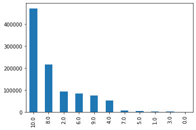

```python
rec_Data.score.value_counts().plot(kind='bar')
plt.show()
```

#### Identify the most rated features.

```python
from sklearn.feature_extraction.text import CountVectorizer
```

```python
# initialize vectorizer
#vect = CountVectorizer(analyzer='word',ngram_range=(1,2),stop_words='english', min_df = 0.001)
vect = CountVectorizer(analyzer='word',ngram_range=(1,2),stop_words='english', min_df = 0.002) #min_df - rare words , max_df - most used words
#ngram_range = (1,2) - if used more than 1(value), lot of features or noise
```

```python
vect.fit(rec_Data['product'])
product_matrix = vect.transform(rec_Data['product'])
```

```python
product_matrix.shape
```

```
(1000000, 935)
```

```python
# Find vocabulary
features = vect.get_feature_names()
features
```

```
['00',
 '01',
 '0ghz',
 '0mp',
 '10',
 '10 cm',
 '11',
 '11 cm',
 '12',
 '12 cm',
 '128',
 '128 gb',
 '1280',
 '1280 720',
 '128gb',
 '13',
 '13 cm',
 '13 megapixel',
 '13 mp',
 '13mp',
 '13mp camera',
 '14',
 '14 cm',
 '16',
 '16 double',
 '16 gb',
 '16 mp',
 '16g',
 '16gb',
 '16gb 4g',
 '16gb black',
 '16gb factory',
 '16gb interner',
 '16gb mobile',
 '16gb rom',
 '16gb unlocked',
 '16gb verizon',
 '16gb white',
 '16gb ðµñ',
 '16mp',
```

[output cut: 880 more lines]

```
 'ðµñ ð¾ð½',
 'ð¹',
 'ð¹ ðµð',
 'ð¼ð',
 'ð¼ð ð¾ð½',
 'ð½ñ',
 'ð½ñ ð¹',
 'ð¾ð',
 'ð¾ð ð½ñ',
 'ð¾ð²ñ',
 'ð¾ð²ñ ð¹',
 'ð¾ð½',
 'ð¾ð½ samsung',
 'ð¾ñ',
 'ð¾ñ ð¾ð²ñ']
```

```python
len(features)
```

```
935
```

```python
# confirm count of features in the corpus
#word_count = [rec_Data["product"].str.contains("\\b"+x+"\\b", case=False).sum() for x in features]
#word_count
```

```python
#feature_list=[]
#count_list=[]
#for x,y in zip(features,word_count):
    #print (x,y,"\n")
#    feature_list.append(x)
#    count_list.append(y)
```

```python
#data = {'feature':feature_list,'counts':count_list}
#feature_Data=pd.DataFrame(data)
#feature_Data.sort_values(by='counts',ascending=False).head(10)
```

#### 3. Select the data with products having more than 50 ratings and users who have given more than 50 ratings. Report the shape of the final dataset.

```python
#selected_Data = rec_Data[rec_Data.groupby('product')['score'].count()>50]
selected_Data = rec_Data.groupby('product').filter(lambda g:g.score.count()>50)
```

```python
selected_Data.shape
```

```
(570039, 5)
```

```python
selected_Data = selected_Data.groupby('author').filter(lambda g:g.score.count()>50)
```

```python
selected_Data.head()
```

|  | score | score_max | extract | author | product |
| --- | --- | --- | --- | --- | --- |
| 3 | 10.0 | 10.0 | very good product from HTC | amazon customer | htc desire 10 lifestyle (polar white, 32 gb) -... |
| 33 | 10.0 | 10.0 | Bonjour, La coque est parfaitement adaptÃ©e au... | client d'amazon | aicek coque samsung galaxy a3 2016, aicek etui... |
| 44 | 8.0 | 10.0 | Only heating issue other wise good product bes... | amazon customer | motorola moto g5 (3 gb, lunar grey) |
| 51 | 4.0 | 10.0 | Good budget smartphone but battery backup is poor | amazon customer | yu yunique yu4711 smartphone (black) |
| 70 | 10.0 | 10.0 | Ottimo prodotto, pienamente conforme alla desc... | massimiliano | samsung c3520, telefono cellulare, argento [ge... |

```python
selected_Data.shape
```

```
(107734, 5)
```

### 3. Build a popularity based model and recommend top 5 mobile phones.

```python
ratings_mean_count = pd.DataFrame(selected_Data.groupby('product')['score'].mean())
```

```python
ratings_mean_count['rating_counts'] = pd.DataFrame(selected_Data.groupby('product')\
                                                   ['score'].count())
```

### Top 5 products based on highest ratings

```python
ratings_mean_count.sort_values(by='score',ascending=False).head()
```

| product | score | rating_counts |
| --- | --- | --- |
| samsung galaxy s plus gt-i9001 | 10.0 | 1 |
| samsung i9000 galaxy s | 10.0 | 2 |
| samsung i9100 galaxy s ii | 10.0 | 3 |
| samsung galaxy s5 - blanc - smartphone | 10.0 | 2 |
| htc rhyme | 10.0 | 2 |

### Top 5 products based on number of ratings

```python
ratings_mean_count.sort_values(by='rating_counts',ascending=False).head()
```

| product | score | rating_counts |
| --- | --- | --- |
| lenovo vibe k4 note (white,16gb) | 7.078290 | 2363 |
| lenovo vibe k4 note (black, 16gb) | 7.081527 | 1938 |
| oneplus 3 (graphite, 64 gb) | 8.488326 | 1499 |
| oneplus 3 (soft gold, 64 gb) | 8.242921 | 1342 |
| lenovo vibe k5 (gold, volte update) | 6.656887 | 1227 |

```python
ratings_pivot = pd.pivot_table(data=ratings_mean_count, values=['rating_counts','score'], columns='product')

ratings_pivot.transpose().head()
```

| product | rating_counts | score |
| --- | --- | --- |
| 5.5-inch unlocked lenovo a850 3g smartphone-(960x540) quad core 4gb mt6582m 1331mhz android 4.2 dual camera +dual sim -black (rooted + google play) | 4.0 | 4.500000 |
| access-discount samsung galaxy j3 2016 coque silicone gel tpu + film protection ecran en verre trempã© galaxy j3 (2016) j320f j3-6 | 58.0 | 6.551724 |
| acer liquid | 1.0 | 9.000000 |
| acer liquid e | 4.0 | 7.250000 |
| acer liquid e2 duo 11,4 cm (4,5 zoll) smartphone (touchscreen, dual-sim, 1,2ghz quadcore prozessor, 1gb ram, 8 megapixel kamera, android 4.2) weiã | 16.0 | 7.000000 |

```python
ratings_pivot.transpose().sort_values(by='rating_counts',ascending=False).head()
```

| product | rating_counts | score |
| --- | --- | --- |
| lenovo vibe k4 note (white,16gb) | 2363.0 | 7.078290 |
| lenovo vibe k4 note (black, 16gb) | 1938.0 | 7.081527 |
| oneplus 3 (graphite, 64 gb) | 1499.0 | 8.488326 |
| oneplus 3 (soft gold, 64 gb) | 1342.0 | 8.242921 |
| lenovo vibe k5 (gold, volte update) | 1227.0 | 6.656887 |

### 4. Build a collaborative filtering model using SVD.

##### 1. You can use SVD from surprise or build it from scratch(Note: Incase you’re building it from scratch you can limit your data points to 5000 samples if you face memory issues).

#### 2. Build a collaborative iltering model using kNNWithMeans from surprise.

#### 3. You can try both user-based and item-based model.

### 1. Collaboartive filtering model using SVD from surprise.

```python
from surprise import SVD
from surprise import Dataset
from surprise import Reader
from surprise.model_selection import cross_validate, KFold
from surprise import accuracy
from surprise.model_selection import train_test_split
```

```python
selected_Data['raw_ratings'] = selected_Data['score']
selected_Data.head()
```

|  | score | score_max | extract | author | product | raw_ratings |
| --- | --- | --- | --- | --- | --- | --- |
| 3 | 10.0 | 10.0 | very good product from HTC | amazon customer | htc desire 10 lifestyle (polar white, 32 gb) -... | 10.0 |
| 33 | 10.0 | 10.0 | Bonjour, La coque est parfaitement adaptÃ©e au... | client d'amazon | aicek coque samsung galaxy a3 2016, aicek etui... | 10.0 |
| 44 | 8.0 | 10.0 | Only heating issue other wise good product bes... | amazon customer | motorola moto g5 (3 gb, lunar grey) | 8.0 |
| 51 | 4.0 | 10.0 | Good budget smartphone but battery backup is poor | amazon customer | yu yunique yu4711 smartphone (black) | 4.0 |
| 70 | 10.0 | 10.0 | Ottimo prodotto, pienamente conforme alla desc... | massimiliano | samsung c3520, telefono cellulare, argento [ge... | 10.0 |

```python
drop_list = ['score','score_max','extract']
selected_Data.drop(drop_list,axis=1,inplace=True)
```

```python
selected_Data.head()
```

|  | author | product | raw_ratings |
| --- | --- | --- | --- |
| 3 | amazon customer | htc desire 10 lifestyle (polar white, 32 gb) -... | 10.0 |
| 33 | client d'amazon | aicek coque samsung galaxy a3 2016, aicek etui... | 10.0 |
| 44 | amazon customer | motorola moto g5 (3 gb, lunar grey) | 8.0 |
| 51 | amazon customer | yu yunique yu4711 smartphone (black) | 4.0 |
| 70 | massimiliano | samsung c3520, telefono cellulare, argento [ge... | 10.0 |

```python
df = pd.DataFrame(selected_Data)
reader = Reader(rating_scale=(1, 10))
# Loads Pandas dataframe
data = Dataset.load_from_df(df[["author", "product", "raw_ratings"]], reader)
```

```python
algo_svd = SVD()
# Run 5-fold cross-validation and then print results
cross_validate(algo_svd, data, measures=['RMSE', 'MAE'], cv=5, verbose=True)
```

```
Evaluating RMSE, MAE of algorithm SVD on 5 split(s).

                  Fold 1  Fold 2  Fold 3  Fold 4  Fold 5  Mean    Std
RMSE (testset)    2.6942  2.6991  2.7084  2.6985  2.7237  2.7048  0.0105
MAE (testset)     2.0808  2.0794  2.0911  2.0777  2.1129  2.0884  0.0131
Fit time          5.20    3.91    4.16    4.90    5.14    4.66    0.52
Test time         0.24    0.24    0.12    0.12    0.13    0.17    0.06
```

```
{'test_rmse': array([2.69419312, 2.69910368, 2.70842208, 2.69854567, 2.72366979]),
 'test_mae': array([2.08084945, 2.0794354 , 2.09111361, 2.07769551, 2.11289007]),
 'fit_time': (5.2005767822265625,
  3.9149887561798096,
  4.161236524581909,
  4.89580512046814,
  5.135782957077026),
 'test_time': (0.24480509757995605,
  0.24222397804260254,
  0.11568260192871094,
  0.11549139022827148,
  0.12583398818969727)}
```

### SVD with train, test split

```python
trainset, testset = train_test_split(data, test_size=.20)
```

```python
algo_svd = SVD()
# Run 5-fold cross-validation and then print results
algo_svd.fit(trainset)
```

```
<surprise.prediction_algorithms.matrix_factorization.SVD at 0x7fb3a80589d0>
```

```python
predictions = algo_svd.test(testset)
predictions
```

```
[Prediction(uid='fred', iid="ivoler samsung galaxy a3 (2016) protection ã©cran, ivoler film protection d'ã©cran en verre trempã© glass screen protector vitre tempered pour samsung galaxy a3 (2016) sm-a310f- duretã© 9h, ultra-mince 0.20 mm, 2.5d bords arrondis- anti-rayure, anti-traces de doigts,", r…
 Prediction(uid='qantas', iid='motorola razr i', r_ui=8.0, est=8.15761134091034, details={'was_impossible': False}),
 Prediction(uid='amazon kunde', iid='honor 7 smartphone (13,2 cm (5,2 zoll) touchscreen, 16gb interner speicher, android os) grau', r_ui=8.0, est=9.42021634979262, details={'was_impossible': False}),
 Prediction(uid='amazon customer', iid='lenovo vibe k4 note (black, 16gb)', r_ui=4.0, est=6.80642871930848, details={'was_impossible': False}),
 Prediction(uid='e-bit', iid='smartphone motorola moto z play xt1635', r_ui=10.0, est=9.53621485953272, details={'was_impossible': False}),
 Prediction(uid='amazon customer', iid='motorola moto g, 4th gen (black, 2 gb, 16 gb)', r_ui=2.0, est=5.911789104923723, details={'was_impossible': False}),
 Prediction(uid='anonymous', iid='lg chocolate touch vx8575', r_ui=10.0, est=9.816669209403127, details={'was_impossible': False}),
 Prediction(uid='amazon customer', iid='motorola moto z play with style mod (black, 32gb)', r_ui=8.0, est=7.80068231589103, details={'was_impossible': False}),
 Prediction(uid='amazon customer', iid='lenovo vibe k4 note (white,16gb)', r_ui=2.0, est=7.991974271945432, details={'was_impossible': False}),
 Prediction(uid='unknown', iid='microsoft nokia lumia 830 smartphone (5 zoll (12,7 cm) touch-display, 16 gb speicher, windows 8.1) schwarz', r_ui=10.0, est=8.10908819629953, details={'was_impossible': False}),
 Prediction(uid='max', iid='cubot 16g cubot s208 economico quad core cellulare smartphone 5.0" ips ogs display otg dual sim google android in offerta - nero', r_ui=6.0, est=7.983738165185095, details={'was_impossible': False}),
 Prediction(uid='vicky', iid='samsung galaxy j3 (8gb)', r_ui=6.0, est=8.61559090415305, details={'was_impossible': False}),
 Prediction(uid='e-bit', iid='smartphone nokia lumia 530', r_ui=10.0, est=8.632387055951929, details={'was_impossible': False}),
 Prediction(uid='amazon customer', iid='lenovo a2010 4g (black)', r_ui=2.0, est=8.103119930465802, details={'was_impossible': False}),
 Prediction(uid='alexander', iid='htc desire c smartphone (8,9 cm (3,5 zoll) hvga-touchscreen, 5 megapixel kamera, 600mhz, 512mb ram, 4gb speicher, android 4.0 os) stealth black', r_ui=10.0, est=7.747670490744888, details={'was_impossible': False}),
 Prediction(uid='amazon customer', iid='samsung galaxy s7 edge factory unlocked phone 32 gb international version (black onyx)', r_ui=8.0, est=7.381845611067085, details={'was_impossible': False}),
 Prediction(uid='amazon customer', iid='sony xperia z3+ (aqua green, 32gb)', r_ui=10.0, est=5.024555260338449, details={'was_impossible': False}),
 Prediction(uid='manuel', iid='microsoft lumia 640 - smartphone libre windows phone (pantalla 5", 8 gb, quad-core 1.2 ghz, 1 gb ram), blanco', r_ui=10.0, est=9.711722369957391, details={'was_impossible': False}),
 Prediction(uid='amazon customer', iid='lenovo vibe k5 (gold, volte update)', r_ui=6.0, est=6.155536261303705, details={'was_impossible': False}),
 Prediction(uid='cliente amazon', iid='samsung g920 galaxy s6 smartphone, 32 gb, oro [italia]', r_ui=8.0, est=7.345479638541974, details={'was_impossible': False}),
 Prediction(uid='amazon customer', iid='oppo digital f1 plus (gold, 4gb)', r_ui=10.0, est=7.487451986659606, details={'was_impossible': False}),
 Prediction(uid="client d'amazon", iid='motorola moto g 3ã¨me gã©nã©ration smartphone dã©bloquã© 4g (ecran: 5 pouces - 8 go - 1 go ram - simple micro-sim - android 5.1) blanc', r_ui=8.0, est=9.163033017688786, details={'was_impossible': False}),
 Prediction(uid='amazon customer', iid='sony xperia m4 aqua 16gb gsm/lte unlocked cell phone - black (u.s. warranty)', r_ui=10.0, est=7.561611427722571, details={'was_impossible': False}),
 Prediction(uid='ð\x9añ\x80ð¸ñ\x81ñ\x82ð¸ð½ð°', iid='sony xperia z1 compact (ñ\x80ð¾ð·ð¾ð²ñ\x8bð¹)', r_ui=10.0, est=9.508744649788937, details={'was_impossible': False}),
 Prediction(uid='amazon customer', iid='lenovo phab 2 plus smartphone (gold, jbl earphones)', r_ui=6.0, est=4.515862077343011, details={'was_impossible': False}),
 Prediction(uid='amazon customer', iid='oneplus 3t (gunmetal, 6gb ram + 64gb memory)', r_ui=10.0, est=9.029039401254398, details={'was_impossible': False}),
```

[output cut: 975 more lines]

```python
accuracy.rmse(predictions)
```

```
RMSE: 2.6983
```

```
2.698276955118801
```

```python
from collections import defaultdict
def get_top_n(predictions, n=5):
    # First map the predictions to each user.
    top_n = defaultdict(list)
    for author, product, true_r, est, _ in predictions:
        top_n[author].append((product, est))

    # Then sort the predictions for each author and retrieve the k highest ones.
    for author, est in top_n.items():
        est.sort(key=lambda x: x[1], reverse=True)
        top_n[author] = est[:n]

    return top_n
```

```python
top_n = get_top_n(predictions, n=5)
top_n
```

```
defaultdict(list,
            {'fred': [('samsung galaxy s7 edge zwart / 32 gb',
               9.549914604487487),
              ('nokia lumia 735 smartphone dã©bloquã© 4g (ecran : 4.7 pouces - 8 go - windows phone 8) vert',
               9.167472886034421),
              ('huawei p8lite zwart / 16 gb', 8.975353471996273),
              ('apple iphone 5s 16 go or', 8.451590897165682),
              ('samsung galaxy note ii n7100 smartphone 16gb (14 cm (5,5 zoll) amoled-touchscreen, quad-core, 1,6ghz, 8 megapixel kamera, android 4.1) blue',
               8.272172508494158)],
             'qantas': [('nokia lumia 920', 9.158372998918013),
              ('samsung galaxy s4 active', 9.012485825431721),
              ('samsung galaxy express i8730', 8.59718568895534),
              ('samsung galaxy express i8730', 8.59718568895534),
              ('samsung galaxy note', 8.457356553420565)],
             'amazon kunde': [('htc 10 smartphone (13,2 cm (5,2 zoll) super lcd 5 display, 1440 x 2560 pixel, 12 ultrapixel, 32 gb, android) glacier silber',
               9.683214284799767),
              ('samsung e1270 klapphandy (4,5 cm (1,8 zoll) tft farbdisplay) rot',
               9.638824375802095),
              ('samsung galaxy j5 smartphone (5 zoll (12,7 cm) touch-display, 8 gb speicher, android 5.1) weiã\x9f',
               9.569680734894218),
              ('samsung galaxy j5 smartphone (5 zoll (12,7 cm) touch-display, 8 gb speicher, android 5.1) weiã\x9f',
               9.569680734894218),
              ('samsung galaxy j5 smartphone (5 zoll (12,7 cm) touch-display, 8 gb speicher, android 5.1) weiã\x9f',
               9.569680734894218)],
             'amazon customer': [('motorola moto x pure edition unlocked smartphone, 64 gb black xt1575, 5.7" quad hd display, 21 mp camera, quad-core 1.8ghz',
               10),
              ('motorola moto x pure edition unlocked smartphone, 64 gb black xt1575, 5.7" quad hd display, 21 mp camera, quad-core 1.8ghz',
               10),
              ('motorola moto x pure edition unlocked smartphone, 64 gb black xt1575, 5.7" quad hd display, 21 mp camera, quad-core 1.8ghz',
               10),
              ('motorola moto x pure edition unlocked smartphone, 64 gb black xt1575, 5.7" quad hd display, 21 mp camera, quad-core 1.8ghz',
               10),
              ('motorola moto x pure edition unlocked smartphone, 64 gb black xt1575, 5.7" quad hd display, 21 mp camera, quad-core 1.8ghz',
               10)],
             'e-bit': [('apple iphone 6 16gb', 9.950608700649171),
              ('apple iphone 6 16gb', 9.950608700649171),
              ('apple iphone 6 16gb', 9.950608700649171),
              ('apple iphone 6s 64gb', 9.950308543547049),
              ('apple iphone 6s 64gb', 9.950308543547049)],
             'anonymous': [('apple iphone 7, 32gb - black', 9.95189617531217),
```

[output cut: 2988 more lines]

```
               7.489484592812297),
              ('oneplus 3t (soft gold, 6gb ram + 64gb memory)',
               7.435202328172602),
              ('motorola moto e 2nd generation xt1506 (3g, black)',
               7.3919813791753715)],
             'domenico': [('asus zenfone 5 smartphone, 8 gb, ram 2 gb, nero [italia]',
               9.845022616064966),
              ('huawei p8 lite smartphone, display 5.0" ips, dual sim, processore octa-core, memoria 16 gb, fotocamera 13 mp, android 5.0, bianco',
               9.831015543582067),
              ('lenovo motorola moto g 4g (2 generazione) smartphone, display 5 pollici, lte, fotocamera 8 mp, memoria 8 gb, android 5 lollipop, nero [italia]',
               9.752262072615514),
              ('honor 7 smartphone 4g, display full hd 5.2 pollici, processore kirin 935 octa core 2.2 ghz, 16 gb memoria interna, 3 gb ram, fotocamera 20 mp, argento',
               9.706282348193149),
              ('huawei mate 8 smartphone dual sim, display da 6" full hd, fotocamera da 16 megapixel, argento',
               9.580687621565891)]})
```

```python
# Print the recommended items for each user
for author, est in top_n.items():
    print(author, [product for (product, _) in est])
```

```
fred ['samsung galaxy s7 edge zwart / 32 gb', 'nokia lumia 735 smartphone dã©bloquã© 4g (ecran : 4.7 pouces - 8 go - windows phone 8) vert', 'huawei p8lite zwart / 16 gb', 'apple iphone 5s 16 go or', 'samsung galaxy note ii n7100 smartphone 16gb (14 cm (5,5 zoll) amoled-touchscreen, quad-core, 1,6gh…
qantas ['nokia lumia 920', 'samsung galaxy s4 active', 'samsung galaxy express i8730', 'samsung galaxy express i8730', 'samsung galaxy note']
amazon kunde ['htc 10 smartphone (13,2 cm (5,2 zoll) super lcd 5 display, 1440 x 2560 pixel, 12 ultrapixel, 32 gb, android) glacier silber', 'samsung e1270 klapphandy (4,5 cm (1,8 zoll) tft farbdisplay) rot', 'samsung galaxy j5 smartphone (5 zoll (12,7 cm) touch-display, 8 gb speicher, android 5.1) …
amazon customer ['motorola moto x pure edition unlocked smartphone, 64 gb black xt1575, 5.7" quad hd display, 21 mp camera, quad-core 1.8ghz', 'motorola moto x pure edition unlocked smartphone, 64 gb black xt1575, 5.7" quad hd display, 21 mp camera, quad-core 1.8ghz', 'motorola moto x pure edition u…
e-bit ['apple iphone 6 16gb', 'apple iphone 6 16gb', 'apple iphone 6 16gb', 'apple iphone 6s 64gb', 'apple iphone 6s 64gb']
anonymous ['apple iphone 7, 32gb - black', 'samsung star', 'lg chocolate touch vx8575', 'lg chocolate touch vx8575', 'nokia n900 black unlocked 3g gsm smart phone/ mobile computer with maemo operating system']
unknown ['samsung samsung galaxy a5 2016 - wit', 'samsung samsung galaxy a5 2016 - wit', 'samsung samsung galaxy a5 2016 - wit', 'samsung samsung galaxy a5 2016 - wit', 'samsung samsung galaxy a5 2016 - wit']
max ['huawei p9 lite smartphone, 5.2" full hd, 3 gb ram, 16 gb, nero, garanzia europa', 'nokia 5230 navigation edition', 'huawei p8 grijs / 16 gb', 'nokia lumia 800 cyan blue', 'lenovo motorola moto g lte smartphone, display 4.5", fotocamera 5 mp, memoria 8 gb, quad-core 1.2 ghz, 1 gb ram, micro sd,…
vicky ['samsung b2100 solid extreme sim free mobile phone', 'sony xperia x compact - unlocked smartphone - 32gb - black (us warranty)', 'samsung galaxy j3 (8gb)', 'microsoft nokia lumia 638 (black)', 'vodafone smart first 6 pay as you go handset smartphone - black']
alexander ['samsung galaxy s4 smartphone (12,7 cm (4,9 zoll) amoled-touchscreen, 16gb interner speicher, 13 megapixel kamera, lte, android 5.0) - schwarz [eu-version]', 'htc one smartphone (11,9 cm (4,7 zoll) touchscreen, ultrapixel kamera, 1,7 ghz, 2 gb ram, lte, nfc-fã¤hig, blinkfeed, boomsound, m…
manuel ['lenovo motorola moto g lte smartphone, display 4.5", fotocamera 5 mp, memoria 8 gb, quad-core 1.2 ghz, 1 gb ram, micro sd, android 4.4.3, bianco [italia]', 'microsoft lumia 640 - smartphone libre windows phone (pantalla 5", 8 gb, quad-core 1.2 ghz, 1 gb ram), blanco', 'microsoft lumia 640 -…
cliente amazon ['honor 7 - smartphone libre de 5.2" (4g, wifi, bluetooth, dual nano sim, hisilicon kirin 935, 64 bit super 8+1 core, 2.2 ghz, 3 gb de ram, 16 gb rom, cã¡mara de 20 mp/8 mp, android 5.0 con emui 3.1) color plateado', 'honor 7 - smartphone libre de 5.2" (4g, wifi, bluetooth, dual nano …
client d'amazon ['aicek coque asus zenfone 2 ze550ml/ze551ml, aicek etui silicone gel asus zenfone 2 housse antichoc zenfone 2 transparente souple coque de protection pour asus zenfone 2(5.5 pouces)', 'aicek coque asus zenfone 2 ze550ml/ze551ml, aicek etui silicone gel asus zenfone 2 housse antichoc…
ðñð¸ññð¸ð½ð° ['apple iphone 5s 16gb (ñ\x81ðµñ\x80ðµð±ñ\x80ð¸ñ\x81ñ\x82ñ\x8bð¹)', 'apple iphone 5s 16gb (ñ\x81ðµñ\x80ñ\x8bð¹ ðºð¾ñ\x81ð¼ð¾ñ\x81)', 'sony xperia z1 compact (ñ\x80ð¾ð·ð¾ð²ñ\x8bð¹)', 'samsung s7270 galaxy ace 3 (ð±ðµð»ñ\x8bð¹)', 'sony xperia z1 (ð±ðµð»ñ\x8bð¹)']
ðð»ðµðºñð°ð½ð´ñ ['samsung galaxy s7', 'samsung galaxy note5', 'samsung galaxy a5 (2016)', 'ð¡ð¼ð°ñ\x80ñ\x82ñ\x84ð¾ð½ apple iphone 5s 16gb space gray me432ru/a', 'samsung galaxy s5 mini']
alberto ['lg nexus 5 smartphone, memoria 16gb, android 4.4, nero [italia]', 'alcatel one touch 20-04g telefono cellulare, nero', 'lenovo motorola moto g smartphone, 4,5 pollici display hd, processore qualcomm, memoria 16gb, microsim, android 4.3 os, fotocamera da 5 mp, nero [germania]', 'huawei asce…
cristina ['samsung j320 galaxy j3 (2016) dual sim 5", quad core, 8gb lte, nero [italia]', 'huawei p9 lite smartphone, lte, display 5,2â\x80\x9d fhd, ips, processore kirin 650, 3 gb ram, fotocamera 13 mp, nero, (marchio tim) [versione italia]', 'samsung galaxy j5 smartphone, oro [italia]', 'samsung g…
```

[output cut: 357 more lines]

### 2. Build a collaborative iltering model using kNNWithMeans from surprise.

#### 1. User-user based model

#### Collaborative filtering with kNNWithMeans from surprise.

```python
from surprise import KNNWithMeans
```

```python
# Use user_based true/false to switch between user-based or item-based collaborative filtering
algo_user = KNNWithMeans(k=50, sim_options={'name': 'pearson_baseline', 'user_based': True})
algo_user.fit(trainset)
```

```
Estimating biases using als...
Computing the pearson_baseline similarity matrix...
Done computing similarity matrix.
```

```
<surprise.prediction_algorithms.knns.KNNWithMeans at 0x7fb3a3c2ce50>
```

```python
# run the trained model against the testset
test_pred_user = algo_user.test(testset)
```

```python
test_pred_user
```

```
[Prediction(uid='fred', iid="ivoler samsung galaxy a3 (2016) protection ã©cran, ivoler film protection d'ã©cran en verre trempã© glass screen protector vitre tempered pour samsung galaxy a3 (2016) sm-a310f- duretã© 9h, ultra-mince 0.20 mm, 2.5d bords arrondis- anti-rayure, anti-traces de doigts,", r…
 Prediction(uid='qantas', iid='motorola razr i', r_ui=8.0, est=8.01696644978732, details={'actual_k': 3, 'was_impossible': False}),
 Prediction(uid='amazon kunde', iid='honor 7 smartphone (13,2 cm (5,2 zoll) touchscreen, 16gb interner speicher, android os) grau', r_ui=8.0, est=9.380817340635506, details={'actual_k': 43, 'was_impossible': False}),
 Prediction(uid='amazon customer', iid='lenovo vibe k4 note (black, 16gb)', r_ui=4.0, est=7.52, details={'actual_k': 50, 'was_impossible': False}),
 Prediction(uid='e-bit', iid='smartphone motorola moto z play xt1635', r_ui=10.0, est=9.575757575757576, details={'actual_k': 33, 'was_impossible': False}),
 Prediction(uid='amazon customer', iid='motorola moto g, 4th gen (black, 2 gb, 16 gb)', r_ui=2.0, est=6.36, details={'actual_k': 50, 'was_impossible': False}),
 Prediction(uid='anonymous', iid='lg chocolate touch vx8575', r_ui=10.0, est=9.962759393900685, details={'actual_k': 4, 'was_impossible': False}),
 Prediction(uid='amazon customer', iid='motorola moto z play with style mod (black, 32gb)', r_ui=8.0, est=8.4, details={'actual_k': 50, 'was_impossible': False}),
 Prediction(uid='amazon customer', iid='lenovo vibe k4 note (white,16gb)', r_ui=2.0, est=7.48, details={'actual_k': 50, 'was_impossible': False}),
 Prediction(uid='unknown', iid='microsoft nokia lumia 830 smartphone (5 zoll (12,7 cm) touch-display, 16 gb speicher, windows 8.1) schwarz', r_ui=10.0, est=10, details={'actual_k': 1, 'was_impossible': False}),
 Prediction(uid='max', iid='cubot 16g cubot s208 economico quad core cellulare smartphone 5.0" ips ogs display otg dual sim google android in offerta - nero', r_ui=6.0, est=7.802189100088097, details={'actual_k': 7, 'was_impossible': False}),
 Prediction(uid='vicky', iid='samsung galaxy j3 (8gb)', r_ui=6.0, est=9.041491158045813, details={'actual_k': 19, 'was_impossible': False}),
 Prediction(uid='e-bit', iid='smartphone nokia lumia 530', r_ui=10.0, est=8.64, details={'actual_k': 50, 'was_impossible': False}),
 Prediction(uid='amazon customer', iid='lenovo a2010 4g (black)', r_ui=2.0, est=6.68, details={'actual_k': 50, 'was_impossible': False}),
 Prediction(uid='alexander', iid='htc desire c smartphone (8,9 cm (3,5 zoll) hvga-touchscreen, 5 megapixel kamera, 600mhz, 512mb ram, 4gb speicher, android 4.0 os) stealth black', r_ui=10.0, est=7.6191397277045825, details={'actual_k': 6, 'was_impossible': False}),
 Prediction(uid='amazon customer', iid='samsung galaxy s7 edge factory unlocked phone 32 gb international version (black onyx)', r_ui=8.0, est=7.64, details={'actual_k': 50, 'was_impossible': False}),
 Prediction(uid='amazon customer', iid='sony xperia z3+ (aqua green, 32gb)', r_ui=10.0, est=6.486531054639782, details={'actual_k': 38, 'was_impossible': False}),
 Prediction(uid='manuel', iid='microsoft lumia 640 - smartphone libre windows phone (pantalla 5", 8 gb, quad-core 1.2 ghz, 1 gb ram), blanco', r_ui=10.0, est=9.88406156231629, details={'actual_k': 4, 'was_impossible': False}),
 Prediction(uid='amazon customer', iid='lenovo vibe k5 (gold, volte update)', r_ui=6.0, est=7.0, details={'actual_k': 50, 'was_impossible': False}),
 Prediction(uid='cliente amazon', iid='samsung g920 galaxy s6 smartphone, 32 gb, oro [italia]', r_ui=8.0, est=7.657336838805246, details={'actual_k': 48, 'was_impossible': False}),
 Prediction(uid='amazon customer', iid='oppo digital f1 plus (gold, 4gb)', r_ui=10.0, est=7.333333333333333, details={'actual_k': 39, 'was_impossible': False}),
 Prediction(uid="client d'amazon", iid='motorola moto g 3ã¨me gã©nã©ration smartphone dã©bloquã© 4g (ecran: 5 pouces - 8 go - 1 go ram - simple micro-sim - android 5.1) blanc', r_ui=8.0, est=9.047685456394325, details={'actual_k': 25, 'was_impossible': False}),
 Prediction(uid='amazon customer', iid='sony xperia m4 aqua 16gb gsm/lte unlocked cell phone - black (u.s. warranty)', r_ui=10.0, est=7.03788389327145, details={'actual_k': 30, 'was_impossible': False}),
 Prediction(uid='ð\x9añ\x80ð¸ñ\x81ñ\x82ð¸ð½ð°', iid='sony xperia z1 compact (ñ\x80ð¾ð·ð¾ð²ñ\x8bð¹)', r_ui=10.0, est=9.781949433551075, details={'actual_k': 48, 'was_impossible': False}),
 Prediction(uid='amazon customer', iid='lenovo phab 2 plus smartphone (gold, jbl earphones)', r_ui=6.0, est=6.666666666666667, details={'actual_k': 21, 'was_impossible': False}),
 Prediction(uid='amazon customer', iid='oneplus 3t (gunmetal, 6gb ram + 64gb memory)', r_ui=10.0, est=8.0, details={'actual_k': 50, 'was_impossible': False}),
```

[output cut: 975 more lines]

1. Evaluate the collaborative model. Print RMSE value.

```python
# get RMSE
print("User-based Model : Test Set")
accuracy.rmse(test_pred_user, verbose=True)
```

```
User-based Model : Test Set
RMSE: 2.7826
```

```
2.7826098205686383
```

### 6. Predict score (average rating) for test users.

```python
# Query for specific predicions
uid = str("uk guest")  # raw user id
iid = str("siemens mc60")  # raw item id
```

```python
# get a prediction for specific users and items.
pred = algo_user.predict(uid, iid, verbose=True)
print(pred)
```

```
user: uk guest   item: siemens mc60 r_ui = None   est = 8.00   {'actual_k': 1, 'was_impossible': False}
user: uk guest   item: siemens mc60 r_ui = None   est = 8.00   {'actual_k': 1, 'was_impossible': False}
```

### Predictions on test data, best predictions, average ratings

```python
def get_Iu(uid):
 # no of items rated by given user
    try:
        return len(trainset.ur[trainset.to_inner_uid(uid)])
    except ValueError:  # user was not part of the trainset
        return 0

def get_Ui(iid):
   # no of users rated the given item
    try:
        return len(trainset.ir[trainset.to_inner_iid(iid)])
    except ValueError:  # item was not part of the trainset
        return 0

df_pred = pd.DataFrame(test_pred_user, columns=['uid', 'iid', 'rui', 'est', 'details'])
df_pred['n_Itemsu'] = df_pred.uid.apply(get_Iu)
df_pred['n_Usersi'] = df_pred.iid.apply(get_Ui)
df_pred['err'] = abs(df_pred.est - df_pred.rui)
best_predictions = df_pred.sort_values(by='err')[:10]
worst_predictions = df_pred.sort_values(by='err')[-10:]
```

```python
best_predictions
```

|  | uid | iid | rui | est | details | n_Itemsu | n_Usersi | err |
| --- | --- | --- | --- | --- | --- | --- | --- | --- |
| 5462 | capyto | nokia 6300 cep telefonu | 9.0 | 9.0 | {'actual_k': 34, 'was_impossible': False} | 51 | 34 | 0.0 |
| 6726 | okuyan | nokia 5800 xpressmusic cep telefonu | 9.0 | 9.0 | {'actual_k': 50, 'was_impossible': False} | 65 | 67 | 0.0 |
| 3124 | ðñð¸ññð¸ð½ð° | apple iphone 5s 16gb (ñðµñðµð±ñð¸ñññð¹) | 10.0 | 10.0 | {'actual_k': 50, 'was_impossible': False} | 48 | 378 | 0.0 |
| 15084 | amazon customer | ct-miami llc blu life play unlocked dual sim p... | 10.0 | 10.0 | {'actual_k': 1, 'was_impossible': False} | 35120 | 4 | 0.0 |
| 6679 | ozer | nokia 3110 cep telefonu | 9.0 | 9.0 | {'actual_k': 23, 'was_impossible': False} | 83 | 23 | 0.0 |
| 3149 | ozlemce108 | nokia e51 cep telefonu | 9.0 | 9.0 | {'actual_k': 32, 'was_impossible': False} | 57 | 32 | 0.0 |
| 15107 | ð®ñð¸ð¹ | nokia x1-01 | 10.0 | 10.0 | {'actual_k': 1, 'was_impossible': False} | 87 | 5 | 0.0 |
| 6651 | amazon customer | oneplus 3 (graphite, 64 gb) | 8.0 | 8.0 | {'actual_k': 50, 'was_impossible': False} | 35120 | 1194 | 0.0 |
| 9471 | kuzeykizi | nokia n76 cep telefonu | 9.0 | 9.0 | {'actual_k': 28, 'was_impossible': False} | 101 | 28 | 0.0 |
| 6649 | dilemma21 | nokia 3110 cep telefonu | 9.0 | 9.0 | {'actual_k': 23, 'was_impossible': False} | 133 | 23 | 0.0 |

```python
df_pred[['uid','iid','est']].sort_values(by='est',ascending=False).head(10)
```

|  | uid | iid | est |
| --- | --- | --- | --- |
| 20727 | ðð¼ð¸ññð¸ð¹ | samsung galaxy s7 | 10.0 |
| 17940 | marco | microsoft nokia 2323 classic handy (gprs, blue... | 10.0 |
| 3644 | federico | lg g2 smartphone (13,2 cm (5,2 pollici), touch... | 10.0 |
| 4776 | ðð¸ðºð¸ñð° | ð¡ð¼ð°ñññð¾ð½ apple iphone 5s 16gb space gr... | 10.0 |
| 17505 | elena | samsung galaxy ace 2, 96.5 mm (3.8 "), 480 x 8... | 10.0 |
| 13099 | jb | pantech hotshot cdm8992 verizon cdma phone wit... | 10.0 |
| 1209 | andrea | samsung star s5230 smartphone (touchscreen, 3m... | 10.0 |
| 1943 | bruno | honor 7 smartphone dã©bloquã© 4g (ecran: 5,2 p... | 10.0 |
| 21313 | # | sony ericsson xperia x8 | 10.0 |
| 15338 | sabrina | samsung galaxy y s5360 smartphone (7,62 cm (3 ... | 10.0 |

### Predict score (average rating) for test users.

```python
test_users_list = ['amazon customer','max','cliente amazon','angel','mauro']
for user in test_users_list:
    est_rating = df_pred[df_pred['uid']==user].est.mean()
    print("User: ",user,"average rating: ",est_rating)
```

```
User:  amazon customer average rating:  7.064922818487553
User:  max average rating:  7.898627622773618
User:  cliente amazon average rating:  8.239712938137533
User:  angel average rating:  7.796462911337562
User:  mauro average rating:  8.012932317342846
```

### Top 10 predictions for each user

Considered output from user-user based collaborative filtering.

```python
from collections import defaultdict
def get_top_n(test_pred_user, n=10):
    # First map the predictions to each user.
    top_n_user = defaultdict(list)
    for author, product, true_r, est, _ in test_pred_user:
        top_n_user[author].append((product, est))

    # Then sort the predictions for each author and retrieve the k highest ones.
    for author, est in top_n_user.items():
        est.sort(key=lambda x: x[1], reverse=True)
        top_n_user[author] = est[:n]

    return top_n_user
```

```python
top_n_user = get_top_n(test_pred_user, n=10)
top_n_user
```

```
defaultdict(list,
            {'fred': [('apple iphone 5s 16 go or', 10),
              ('nokia lumia 735 smartphone dã©bloquã© 4g (ecran : 4.7 pouces - 8 go - windows phone 8) vert',
               9.89309322791441),
              ('samsung galaxy s7 edge zwart / 32 gb', 9.184816476629985),
              ('samsung galaxy note ii n7100 smartphone 16gb (14 cm (5,5 zoll) amoled-touchscreen, quad-core, 1,6ghz, 8 megapixel kamera, android 4.1) blue',
               9.07787178315262),
              ('huawei p8lite zwart / 16 gb', 8.919489574763524),
              ('samsung galaxy s5 sm-g900a 16gb at&t branded smartphone (unlocked, copper gold)',
               8.497459134890653),
              ('motorola moto g 4g sim-free smartphone - black (8gb) - discontinued by manufacturer',
               8.441147554730604),
              ('nokia lumia 520 gsm unlock 3g phone, 4-inch touch screen, 5mp 720p camera, windows phone (black)',
               7.846220935973398),
              ('cubot note s smartphone ohne vertrag (5.5 zoll (13,9 cm) hd touch-display mit 4150mah akku, 2gb ram/16gb interner speicher, android 6.0, dual-sim, 5mp/8mp dual kamera, quad-core prozessor, ips 2.5d gebogener bildschirm) fã¼r t-mobile, vodafone, o2-de, e-plus usw ',
               7.767247410979926),
              ('samsung i9100 galaxy s2 smartphone android 3g+ wifi 16 go noir',
               7.732558139534884)],
             'qantas': [('nokia 3120 classic', 10),
              ('htc one sv', 10),
              ('samsung galaxy s4 active', 9.987517481473539),
              ('nokia lumia 920', 9.16689158794422),
              ('htc one x', 9.09569714483178),
              ('htc sensation xl', 8.839158217454179),
              ('nokia x3-02', 8.727890849820161),
              ('samsung galaxy express i8730', 8.571428571428571),
              ('samsung galaxy express i8730', 8.571428571428571),
              ('apple iphone 4s 64gb', 8.5)],
             'amazon kunde': [('huawei p8 lite 4g fdd-lte wcdma gsm hisilicon kirin 620 octa core 1.2ghz smartphone 5.0 "tft emui 3.1 compatible con android 5.0 2gb ram 16gb rom 5mp 13mp',
               10),
              ('samsung galaxy j5 smartphone (5 zoll (12,7 cm) touch-display, 8 gb speicher, android 5.1) weiã\x9f',
               10),
              ('blackberry passport smartphone (11,4 cm (4,5 zoll) display, nano-sim, qwertz, 32gb interner speicher, 13 megapixel...',
               10),
              ('samsung galaxy j5 smartphone (5 zoll (12,7 cm) touch-display, 8 gb speicher, android 5.1) weiã\x9f',
               10),
              ('microsoft nokia lumia 720 smartphone (4,3 zoll (10,9 cm) touch-display, 8 gb speicher, windows 8) cyan',
               10),
              ('samsung galaxy j5 smartphone (5 zoll (12,7 cm) touch-display, 8 gb speicher, android 5.1) weiã\x9f',
               10),
```

[output cut: 5721 more lines]

```
              ('asus zenfone 5 smartphone, 8 gb, ram 2 gb, nero [italia]', 10),
              ('honor 7 smartphone 4g, display full hd 5.2 pollici, processore kirin 935 octa core 2.2 ghz, 16 gb memoria interna, 3 gb ram, fotocamera 20 mp, argento',
               9.941267897275162),
              ('huawei mate 8 smartphone dual sim, display da 6" full hd, fotocamera da 16 megapixel, argento',
               9.889700509676599),
              ('lenovo motorola moto g smartphone, 4,5 pollici display hd, processore qualcomm, memoria 16gb, microsim, android 4.3 os, fotocamera da 5 mp, nero [germania]',
               9.705901064356357),
              ('lenovo motorola moto g 4g (2 generazione) smartphone, display 5 pollici, lte, fotocamera 8 mp, memoria 8 gb, android 5 lollipop, nero [italia]',
               9.663290784723253),
              ('alcatel one touch 20-04g telefono cellulare, nero',
               8.919142921848563),
              ('asus zenfone go 5" smartphone, 8 gb, dual sim, bianco [italia]',
               8.80354018426326),
              ('samsung g3500 galaxy core plus smartphone, 4 gb, bianco [italia]',
               8.324071516259728)]})
```

```python
test_users_list = ['amazon customer','max','cliente amazon','angel','mauro']
for item in test_users_list:
    if item in top_n_user:
        value = top_n_user.get(item)
        print("Top 10 Recommendations for Author:",item,"\n")
        count = 1
        for values in value:
            print("Recommended Product ",count,": ", values[0]," \n Rating : ",values[1],"\n")
            count= count+1
```

[output not shown]

### Top 10 predictions for each user

Considered output from the SVD predictions.

```python
from collections import defaultdict
def get_top_n(test_pred, n=10):
    # First map the predictions to each user.
    top_n = defaultdict(list)
    for author, product, true_r, est, _ in test_pred:
        top_n[author].append((product, est))

    # Then sort the predictions for each author and retrieve the k highest ones.
    for author, est in top_n.items():
        est.sort(key=lambda x: x[1], reverse=True)
        top_n[author] = est[:n]

    return top_n
```

```python
top_n = get_top_n(predictions, n=10)
top_n
```

[output not shown]

[output cut: 2986 more lines]

```
              ('samsung gt-s5360 galaxy y smartphone hsdpa/3g/edge/gprs wifi bluetooth gps android gris',
               8.381309095877093),
              ('sony xperia j smartphone (10,2 cm (4 zoll) touchscreen, qualcomm, 1ghz, 512mb ram, 5 megapixel kamera, android 4.0) schwarz',
               8.377439846818131),
              ('samsung galaxy s6 edge smartphone (5,1 zoll (12,9 cm) touch-display, 64 gb speicher, android 5.0) gold',
               7.9993519322069835)],
             'marcus': [('sony xperia z1 compact sim-free android smartphone - black',
               9.094725110114142),
              ('huawei p8 smartphone (5,2 zoll (13,2 cm) touch-display, 16 gb speicher, android 5.0) grau',
               9.093761463122222),
              ('smartphone lg l90 dual d410 preto com tela de 4.7â\x80\x9d, dual chip, android 4.4, cã¢mera 8mp e processador quad core de 1.2 ghz',
               9.016503712614535),
              ('samsung galaxy s7 goud, roze / 32 gb', 8.999034703070958),
              ('microsoft lumia 640 xl single-sim smartphone (5 zoll (12,7 cm) touch-display, 8 gb speicher, windows 8.1) orange',
               8.4812945499646)]})
```

### Item-item collaboarative filtering based recommendation system.

```python
# Use user_based true/false to switch between user-based or item-based collaborative filtering
algo_item = KNNWithMeans(k=50, sim_options={'name': 'pearson_baseline', 'user_based': False})
algo_item.fit(trainset)
```

```
Estimating biases using als...
Computing the pearson_baseline similarity matrix...
Done computing similarity matrix.
```

```
<surprise.prediction_algorithms.knns.KNNWithMeans at 0x7fb402d32350>
```

```python
# run the trained model against the testset
test_pred_item = algo_item.test(testset)
```

```python
# get RMSE
print("Item-based Model : Test Set")
accuracy.rmse(test_pred_item, verbose=True)
```

```
Item-based Model : Test Set
RMSE: 2.7152
```

```
2.7151699472081803
```

```python
print("SVD based Model : Test Set")
accuracy.rmse(predictions,verbose=True)
print("User-based Model : Test Set")
accuracy.rmse(test_pred_user, verbose=True)
print("Item-based Model : Test Set")
accuracy.rmse(test_pred_item, verbose=True)
```

```
SVD based Model : Test Set
RMSE: 2.6983
User-based Model : Test Set
RMSE: 2.7826
Item-based Model : Test Set
RMSE: 2.7152
```

```
2.7151699472081803
```

#### GridSearchCV is applied with similarity measures 'msd' and 'cosine' on use based and item based collaborative fltering.

```python
from surprise.model_selection import GridSearchCV
sim_options = {
    "name": ["msd", "cosine"],
    "min_support": [3, 4, 5],
    "user_based": [False, True],
}

param_grid = {"sim_options": sim_options}

gs = GridSearchCV(KNNWithMeans, param_grid, measures=["rmse", "mae"], cv=3)
gs.fit(data)

print(gs.best_score["rmse"])
print(gs.best_params["rmse"])
```

[output not shown]

```python
param_grid = {
    "n_epochs": [5, 10],
    "lr_all": [0.002, 0.005],
    "reg_all": [0.4, 0.6]
}
gs = GridSearchCV(SVD, param_grid, measures=["rmse", "mae"], cv=3)

gs.fit(data)

print(gs.best_score["rmse"])
print(gs.best_params["rmse"])
```

[output not shown]

### 7. Report your findings and inferences.

#### Used SVD, user-user based and item-item based collaborative filtering.

All the methods gives the rmse is around 2.7 for all methods used.

### 8. Try and recommend top 5 products for test users.

```python
# based on svd predictions
test_users_list = ['amazon customer','max','cliente amazon','angel','mauro']
for item in test_users_list:
    if item in top_n:
        value = top_n.get(item)
        print("Top 5 Recommendations for Author:",item,"\n")
        count = 1
        for values in value:
            print("Recommended Product ",count,": ", values[0]," \n Rating : ",values[1],"\n")
            count= count+1
```

[output not shown]

### 10. Try cross validation techniques to get better results.

```python
cross_validate(algo_svd, data, measures=['RMSE', 'MAE'], cv=5, verbose=True)
```

[output not shown]

```python
cross_validate(algo_user, data, measures=['RMSE', 'MAE'], cv=5, verbose=True)
```

[output not shown]

```python
cross_validate(algo_item, data, measures=['RMSE', 'MAE'], cv=5, verbose=True)
```

[output not shown]

### 11. In what business scenario you should use popularity based Recommendation Systems ?

Popularity based recommendation system provides general recommendations to its users based on the current trend or product popularity or the products purchased by most of the people and rated as high. It takes the average ratings of each product and recommends the topmost products to its users. It does not provide with personal recommendations based on users ineterests or attributes.

Popularity based Recommendation system is used in the following business scenarios:

1. When users disable their tracking information its difficult to get the interests, instead of having zero recommendations, popular products can be recommended.
2. When business is started, and there are no any ratings available. Then popularity of products can be considered. e.g. Popular books, movies etc.
3. When sufficient ratings data is not available for individual users interests. So to start with we can build popularity based recommendation system. When sufficient rating data is collected over time then can shift to personalization based on collaborative filtering methods.

### 12. In what business scenario you should use CF based Recommendation Systems ?

Collaboartive filtering based recommendation system provides personalized recommendations to its users based on users interests or attributes. It can be based on user similarity, in which case recommendations are provided based on users who have purchased the same product. It finds neighbours based on common ratings provided by users. It works by searching a large group of people and finding a smaller set of users with tastes similar to a particular user. It looks at the items they like and combines them to create a ranked list of suggestions. In item-item based recommendation system provides recommendations based on item similarity. Items which has similar ratings can be considered as similar items.

#### Collaborative Filtering based recommendation systems are user in the following business scenarios:

In case sufficient user and rating data is available, can use collaborative filtering recommendation system. It provides personalized ratings useful for better sell of the products and frequent visits by the users/customers. Collaborative filtering doesn’t require features about the items or users to be known. It is suited for a set of different types of items, for example, a supermarket’s inventory where items of various categories can be added.

Although collaborative Filtering is very commonly used in recommenders, some of the challenges that are faced while using it are the following:

Problems with Collaborative filtering:

1. Cold start for new items that are added to the list. Until someone rates them, they don’t get recommended.
2. Data sparsity can affect the quality of user-based recommenders and also add to the cold start problem mentioned above.
3. Scaling can be a challenge for growing datasets as the complexity can become too large. Item-based recommenders are faster than user-based when the dataset is large.

### 13. What other possible methods can you think of which can further improve the recommendation for different users ?

To improve recommendation systems we can use following methods:

1. Hybrid filtering techniques.

#### Hybrid filtering techniques:

Hybrid filtering technique combines different recommendation techniques in order to gain better system optimization to avoid some limitations and problems of pure recommendation systems. In hybrid techniques,a combination of algorithms is used. It will provide more accurate and effective recommendations than a single algorithm as the disadvantages of one algorithm can be overcome by another algorithm. The combination of approaches can be done in any of the following ways:

1. Separate implementation of algorithms and combining the result
2. Utilizing some content-based filtering in collaborative approach
3. Utilizing some collaborative filtering in content-based approach
4. Creating a unified recommendation system that brings together both approaches.

##### Weighted hybridization combines the results of different recommenders to generate a recommendation list or prediction by integrating the scores from each of the techniques in use by a linear formula.

##### Switching hybridization

The system swaps to one of the recommendation techniques according to a heuristic reflecting the recommender ability to produce a good rating. The switching hybrid has the ability to avoid problems specific to one method e.g. the new user problem of content-based recommender, by switching to a collaborative recommendation system. The benefit of this strategy is that the system is sensitive to the strengths and weaknesses of its constituent recommenders.

##### Cascade hybridization

The cascade hybridization technique applies an iterative refinement process in constructing an order of preference among different items. The recommendations of one technique are refined by another recommendation technique. The first recommendation technique outputs a coarse list of recommendations which is in turn refined by the next recommendation technique.

##### Mixed hybridization

Mixed hybrids combine recommendation results of different recommendation techniques at the same time instead of having just one recommendation per item. Each item has multiple recommendations associated with it from different recommendation techniques.

##### Feature-combination

The features produced by a specific recommendation technique are fed into another recommendation technique.

##### Feature-augmentation

Uses ratings and other information from previous recommender. It also requires additional functionality from the recommender systems.

#### Some additional algorithms are applied on the dataset with cross validation with k = 3

#### Algorithms NMF, SlopeOne, NormalPredictor, KNNBaseline,KNNBasic, KNNWithMeans, KNNWithZScore, BaselineOnly, CoClustering are used and rmse is computed for each algorithm.

```python
from surprise import NMF, SVDpp, SlopeOne,NormalPredictor,KNNBaseline,KNNBasic, KNNWithMeans, KNNWithZScore, BaselineOnly, CoClustering
benchmark = []
# Iterate over all algorithms
for algorithm in [SVD(), SVDpp(), SlopeOne(), NMF(), NormalPredictor(), KNNBaseline(), KNNBasic(), KNNWithMeans(), KNNWithZScore(), BaselineOnly(), CoClustering()]:
    # Perform cross validation
    results = cross_validate(algorithm, rec_Data, measures=['RMSE'], cv=3, verbose=False)

    # Get results & append algorithm name
    tmp = pd.DataFrame.from_dict(results).mean(axis=0)
    tmp = tmp.append(pd.Series([str(algorithm).split(' ')[0].split('.')[-1]], index=['Algorithm']))
    benchmark.append(tmp)

pd.DataFrame(benchmark).set_index('Algorithm').sort_values('test_rmse')
```

[output not shown]

```python
benchmark
```

[output not shown]